# Risk Factor Analysis

## Outcome Variable

**Outcome Variable:** sstunted

## Predictor Variables

**Intervention Variable:** hfoodsec

**Adjustment Set:**

unadjusted

## Stratifying Variables

The analysis was stratified on these variable(s):

- agecat
- studyid
- country

## Data Summary

| agecat | studyid | country | hfoodsec | sstunted | n_cell | n |
| --- | --- | --- | --- | --- | --- | --- |
| Birth | ki0047075b-MAL-ED | BANGLADESH | Food Secure | 0 | 153 | 188 |
| Birth | ki0047075b-MAL-ED | BANGLADESH | Food Secure | 1 | 4 | 188 |
| Birth | ki0047075b-MAL-ED | BANGLADESH | Mildly Food Insecure | 0 | 3 | 188 |
| Birth | ki0047075b-MAL-ED | BANGLADESH | Mildly Food Insecure | 1 | 1 | 188 |
| Birth | ki0047075b-MAL-ED | BANGLADESH | Food Insecure | 0 | 26 | 188 |
| Birth | ki0047075b-MAL-ED | BANGLADESH | Food Insecure | 1 | 1 | 188 |
| Birth | ki0047075b-MAL-ED | BRAZIL | Food Secure | 0 | 0 | 105 |
| Birth | ki0047075b-MAL-ED | BRAZIL | Food Secure | 1 | 0 | 105 |
| Birth | ki0047075b-MAL-ED | BRAZIL | Mildly Food Insecure | 0 | 11 | 105 |
| Birth | ki0047075b-MAL-ED | BRAZIL | Mildly Food Insecure | 1 | 0 | 105 |
| Birth | ki0047075b-MAL-ED | BRAZIL | Food Insecure | 0 | 90 | 105 |
| Birth | ki0047075b-MAL-ED | BRAZIL | Food Insecure | 1 | 4 | 105 |
| Birth | ki0047075b-MAL-ED | INDIA | Food Secure | 0 | 150 | 170 |
| Birth | ki0047075b-MAL-ED | INDIA | Food Secure | 1 | 4 | 170 |
| Birth | ki0047075b-MAL-ED | INDIA | Mildly Food Insecure | 0 | 2 | 170 |
| Birth | ki0047075b-MAL-ED | INDIA | Mildly Food Insecure | 1 | 0 | 170 |
| Birth | ki0047075b-MAL-ED | INDIA | Food Insecure | 0 | 13 | 170 |
| Birth | ki0047075b-MAL-ED | INDIA | Food Insecure | 1 | 1 | 170 |
| Birth | ki0047075b-MAL-ED | NEPAL | Food Secure | 0 | 76 | 98 |
| Birth | ki0047075b-MAL-ED | NEPAL | Food Secure | 1 | 0 | 98 |
| Birth | ki0047075b-MAL-ED | NEPAL | Mildly Food Insecure | 0 | 9 | 98 |
| Birth | ki0047075b-MAL-ED | NEPAL | Mildly Food Insecure | 1 | 0 | 98 |
| Birth | ki0047075b-MAL-ED | NEPAL | Food Insecure | 0 | 11 | 98 |
| Birth | ki0047075b-MAL-ED | NEPAL | Food Insecure | 1 | 2 | 98 |
| Birth | ki0047075b-MAL-ED | PERU | Food Secure | 0 | 27 | 107 |
| Birth | ki0047075b-MAL-ED | PERU | Food Secure | 1 | 0 | 107 |
| Birth | ki0047075b-MAL-ED | PERU | Mildly Food Insecure | 0 | 25 | 107 |
| Birth | ki0047075b-MAL-ED | PERU | Mildly Food Insecure | 1 | 0 | 107 |
| Birth | ki0047075b-MAL-ED | PERU | Food Insecure | 0 | 55 | 107 |
| Birth | ki0047075b-MAL-ED | PERU | Food Insecure | 1 | 0 | 107 |

[output cut: 162 more lines]

The following strata were considered:

- agecat: 24 months, studyid: ki0047075b-MAL-ED, country: BANGLADESH
- agecat: 24 months, studyid: ki0047075b-MAL-ED, country: BRAZIL
- agecat: 24 months, studyid: ki0047075b-MAL-ED, country: INDIA
- agecat: 24 months, studyid: ki0047075b-MAL-ED, country: NEPAL
- agecat: 24 months, studyid: ki0047075b-MAL-ED, country: PERU
- agecat: 24 months, studyid: ki0047075b-MAL-ED, country: SOUTH AFRICA
- agecat: 24 months, studyid: ki1017093-NIH-Birth, country: BANGLADESH
- agecat: 24 months, studyid: ki1017093c-NIH-Crypto, country: BANGLADESH
- agecat: 24 months, studyid: ki1113344-GMS-Nepal, country: NEPAL
- agecat: 24 months, studyid: kiGH5241-JiVitA-3, country: BANGLADESH
- agecat: 24 months, studyid: kiGH5241-JiVitA-4, country: BANGLADESH
- agecat: 6 months, studyid: ki0047075b-MAL-ED, country: BANGLADESH
- agecat: 6 months, studyid: ki0047075b-MAL-ED, country: BRAZIL
- agecat: 6 months, studyid: ki0047075b-MAL-ED, country: INDIA
- agecat: 6 months, studyid: ki0047075b-MAL-ED, country: NEPAL
- agecat: 6 months, studyid: ki0047075b-MAL-ED, country: PERU
- agecat: 6 months, studyid: ki0047075b-MAL-ED, country: SOUTH AFRICA
- agecat: 6 months, studyid: ki1017093-NIH-Birth, country: BANGLADESH
- agecat: 6 months, studyid: ki1017093c-NIH-Crypto, country: BANGLADESH
- agecat: 6 months, studyid: ki1113344-GMS-Nepal, country: NEPAL
- agecat: 6 months, studyid: kiGH5241-JiVitA-3, country: BANGLADESH
- agecat: 6 months, studyid: kiGH5241-JiVitA-4, country: BANGLADESH
- agecat: Birth, studyid: ki0047075b-MAL-ED, country: BANGLADESH
- agecat: Birth, studyid: ki0047075b-MAL-ED, country: BRAZIL
- agecat: Birth, studyid: ki0047075b-MAL-ED, country: INDIA
- agecat: Birth, studyid: ki0047075b-MAL-ED, country: NEPAL
- agecat: Birth, studyid: ki0047075b-MAL-ED, country: PERU
- agecat: Birth, studyid: ki0047075b-MAL-ED, country: SOUTH AFRICA
- agecat: Birth, studyid: ki1017093-NIH-Birth, country: BANGLADESH
- agecat: Birth, studyid: ki1017093c-NIH-Crypto, country: BANGLADESH
- agecat: Birth, studyid: kiGH5241-JiVitA-3, country: BANGLADESH
- agecat: Birth, studyid: kiGH5241-JiVitA-4, country: BANGLADESH

### Dropped Strata

Some strata were dropped due to rare outcomes:

- agecat: Birth, studyid: ki0047075b-MAL-ED, country: BANGLADESH
- agecat: Birth, studyid: ki0047075b-MAL-ED, country: BRAZIL
- agecat: Birth, studyid: ki0047075b-MAL-ED, country: INDIA
- agecat: Birth, studyid: ki0047075b-MAL-ED, country: NEPAL
- agecat: Birth, studyid: ki0047075b-MAL-ED, country: PERU
- agecat: Birth, studyid: ki0047075b-MAL-ED, country: SOUTH AFRICA
- agecat: Birth, studyid: ki1017093-NIH-Birth, country: BANGLADESH
- agecat: Birth, studyid: ki1017093c-NIH-Crypto, country: BANGLADESH
- agecat: 6 months, studyid: ki0047075b-MAL-ED, country: BANGLADESH
- agecat: 6 months, studyid: ki0047075b-MAL-ED, country: BRAZIL
- agecat: 6 months, studyid: ki0047075b-MAL-ED, country: INDIA
- agecat: 6 months, studyid: ki0047075b-MAL-ED, country: NEPAL
- agecat: 6 months, studyid: ki0047075b-MAL-ED, country: PERU
- agecat: 6 months, studyid: ki0047075b-MAL-ED, country: SOUTH AFRICA
- agecat: 6 months, studyid: ki1017093-NIH-Birth, country: BANGLADESH
- agecat: 6 months, studyid: ki1017093c-NIH-Crypto, country: BANGLADESH
- agecat: 6 months, studyid: ki1113344-GMS-Nepal, country: NEPAL
- agecat: 24 months, studyid: ki0047075b-MAL-ED, country: BANGLADESH
- agecat: 24 months, studyid: ki0047075b-MAL-ED, country: BRAZIL
- agecat: 24 months, studyid: ki0047075b-MAL-ED, country: INDIA
- agecat: 24 months, studyid: ki0047075b-MAL-ED, country: NEPAL
- agecat: 24 months, studyid: ki0047075b-MAL-ED, country: PERU
- agecat: 24 months, studyid: ki0047075b-MAL-ED, country: SOUTH AFRICA

## Methods Detail

We’re interested in the causal parameters $E[Y_a]$ for all values of $a \in \mathcal{A}$. These parameters represent the mean outcome if, possibly contrary to fact, we intervened to set all units to have $A=a$. Under the randomization and positivity assumptions, these are identified by the statistical parameters $\psi_a=E_W[E_{Y|A,W}(Y|A=a,W)]$. In addition, we’re interested in the mean of $Y$, $E[Y]$ under no intervention (the observed mean). We will estimate these parameters by using SuperLearner to fit the relevant likelihood factors – $E_{Y|A,W}(Y|A=a,W)$ and $p(A=a|W)$, and then updating our likelihood fit using a joint TMLE.

For unadjusted analyses ($W=\{\}$), initial likelihoods were estimated using Lrnr_glm to estimate the simple $E(Y|A)$ and Lrnr_mean to estimate $p(A)$. For adjusted analyses, a small library containing Lrnr_glmnet, Lrnr_xgboost, and Lrnr_mean was used.

Having estimated these parameters, we will then use the delta method to estimate relative risks and attributable risks relative to a prespecified baseline level of $A$.

# Results Detail

## Results Plots

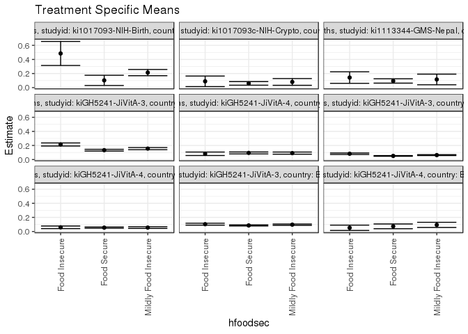

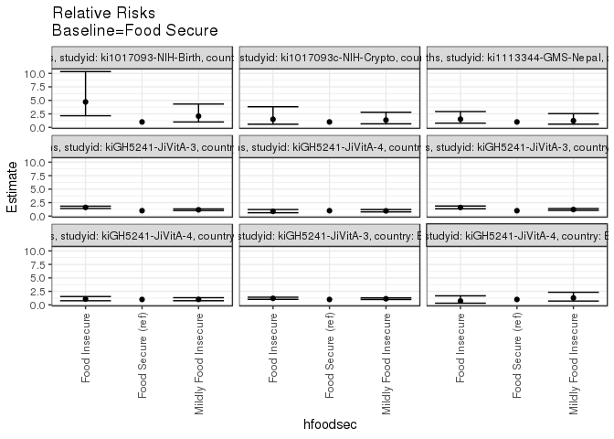

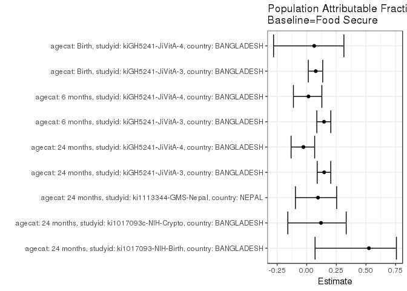

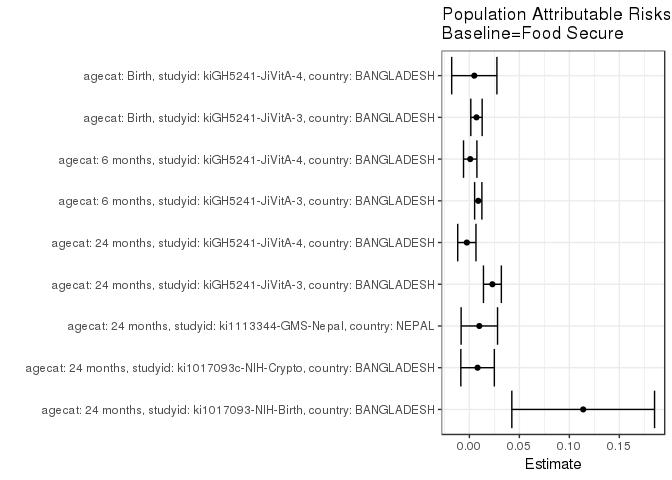

## Results Table

### Parameter: TSM

| agecat | studyid | country | intervention_level | baseline_level | estimate | ci_lower | ci_upper |
| --- | --- | --- | --- | --- | --- | --- | --- |
| Birth | kiGH5241-JiVitA-3 | BANGLADESH | Food Secure | NA | 0.0860430 | 0.0783644 | 0.0937216 |
| Birth | kiGH5241-JiVitA-3 | BANGLADESH | Mildly Food Insecure | NA | 0.0973472 | 0.0879279 | 0.1067664 |
| Birth | kiGH5241-JiVitA-3 | BANGLADESH | Food Insecure | NA | 0.1038275 | 0.0897986 | 0.1178565 |
| Birth | kiGH5241-JiVitA-4 | BANGLADESH | Food Secure | NA | 0.0732323 | 0.0396415 | 0.1068232 |
| Birth | kiGH5241-JiVitA-4 | BANGLADESH | Mildly Food Insecure | NA | 0.0938511 | 0.0574751 | 0.1302272 |
| Birth | kiGH5241-JiVitA-4 | BANGLADESH | Food Insecure | NA | 0.0526316 | 0.0149521 | 0.0903111 |
| 6 months | kiGH5241-JiVitA-3 | BANGLADESH | Food Secure | NA | 0.0518122 | 0.0469616 | 0.0566629 |
| 6 months | kiGH5241-JiVitA-3 | BANGLADESH | Mildly Food Insecure | NA | 0.0631917 | 0.0565245 | 0.0698589 |
| 6 months | kiGH5241-JiVitA-3 | BANGLADESH | Food Insecure | NA | 0.0825523 | 0.0718451 | 0.0932594 |
| 6 months | kiGH5241-JiVitA-4 | BANGLADESH | Food Secure | NA | 0.0548731 | 0.0459034 | 0.0638427 |
| 6 months | kiGH5241-JiVitA-4 | BANGLADESH | Mildly Food Insecure | NA | 0.0555234 | 0.0433035 | 0.0677434 |
| 6 months | kiGH5241-JiVitA-4 | BANGLADESH | Food Insecure | NA | 0.0594855 | 0.0410416 | 0.0779295 |
| 24 months | ki1017093-NIH-Birth | BANGLADESH | Food Secure | NA | 0.1029412 | 0.0306300 | 0.1752524 |
| 24 months | ki1017093-NIH-Birth | BANGLADESH | Mildly Food Insecure | NA | 0.2134146 | 0.1690228 | 0.2578065 |
| 24 months | ki1017093-NIH-Birth | BANGLADESH | Food Insecure | NA | 0.4848485 | 0.3141348 | 0.6555622 |
| 24 months | ki1017093c-NIH-Crypto | BANGLADESH | Food Secure | NA | 0.0598802 | 0.0344101 | 0.0853504 |
| 24 months | ki1017093c-NIH-Crypto | BANGLADESH | Mildly Food Insecure | NA | 0.0806452 | 0.0326728 | 0.1286175 |
| 24 months | ki1017093c-NIH-Crypto | BANGLADESH | Food Insecure | NA | 0.0892857 | 0.0145275 | 0.1640439 |
| 24 months | ki1113344-GMS-Nepal | NEPAL | Food Secure | NA | 0.0945559 | 0.0638263 | 0.1252854 |
| 24 months | ki1113344-GMS-Nepal | NEPAL | Mildly Food Insecure | NA | 0.1159420 | 0.0403232 | 0.1915608 |
| 24 months | ki1113344-GMS-Nepal | NEPAL | Food Insecure | NA | 0.1428571 | 0.0607989 | 0.2249154 |
| 24 months | kiGH5241-JiVitA-3 | BANGLADESH | Food Secure | NA | 0.1331613 | 0.1209224 | 0.1454002 |
| 24 months | kiGH5241-JiVitA-3 | BANGLADESH | Mildly Food Insecure | NA | 0.1553785 | 0.1402208 | 0.1705362 |
| 24 months | kiGH5241-JiVitA-3 | BANGLADESH | Food Insecure | NA | 0.2141952 | 0.1926103 | 0.2357801 |
| 24 months | kiGH5241-JiVitA-4 | BANGLADESH | Food Secure | NA | 0.0942059 | 0.0806131 | 0.1077987 |
| 24 months | kiGH5241-JiVitA-4 | BANGLADESH | Mildly Food Insecure | NA | 0.0914956 | 0.0761348 | 0.1068564 |
| 24 months | kiGH5241-JiVitA-4 | BANGLADESH | Food Insecure | NA | 0.0821018 | 0.0573061 | 0.1068975 |

### Parameter: E(Y)

| agecat | studyid | country | intervention_level | baseline_level | estimate | ci_lower | ci_upper |
| --- | --- | --- | --- | --- | --- | --- | --- |
| Birth | kiGH5241-JiVitA-3 | BANGLADESH | NA | NA | 0.0931376 | 0.0875494 | 0.0987258 |
| Birth | kiGH5241-JiVitA-4 | BANGLADESH | NA | NA | 0.0781441 | 0.0560930 | 0.1001951 |
| 6 months | kiGH5241-JiVitA-3 | BANGLADESH | NA | NA | 0.0606873 | 0.0568242 | 0.0645503 |
| 6 months | kiGH5241-JiVitA-4 | BANGLADESH | NA | NA | 0.0557062 | 0.0489296 | 0.0624829 |
| 24 months | ki1017093-NIH-Birth | BANGLADESH | NA | NA | 0.2167832 | 0.1777459 | 0.2558205 |
| 24 months | ki1017093c-NIH-Crypto | BANGLADESH | NA | NA | 0.0680934 | 0.0462948 | 0.0898920 |
| 24 months | ki1113344-GMS-Nepal | NEPAL | NA | NA | 0.1045082 | 0.0773382 | 0.1316782 |
| 24 months | kiGH5241-JiVitA-3 | BANGLADESH | NA | NA | 0.1561967 | 0.1470936 | 0.1652999 |
| 24 months | kiGH5241-JiVitA-4 | BANGLADESH | NA | NA | 0.0916614 | 0.0822542 | 0.1010685 |

### Parameter: RR

| agecat | studyid | country | intervention_level | baseline_level | estimate | ci_lower | ci_upper |
| --- | --- | --- | --- | --- | --- | --- | --- |
| Birth | kiGH5241-JiVitA-3 | BANGLADESH | Food Secure | Food Secure | 1.0000000 | 1.0000000 | 1.000000 |
| Birth | kiGH5241-JiVitA-3 | BANGLADESH | Mildly Food Insecure | Food Secure | 1.1313779 | 0.9941605 | 1.287535 |
| Birth | kiGH5241-JiVitA-3 | BANGLADESH | Food Insecure | Food Secure | 1.2066933 | 1.0263883 | 1.418672 |
| Birth | kiGH5241-JiVitA-4 | BANGLADESH | Food Secure | Food Secure | 1.0000000 | 1.0000000 | 1.000000 |
| Birth | kiGH5241-JiVitA-4 | BANGLADESH | Mildly Food Insecure | Food Secure | 1.2815534 | 0.7048114 | 2.330239 |
| Birth | kiGH5241-JiVitA-4 | BANGLADESH | Food Insecure | Food Secure | 0.7186933 | 0.3087008 | 1.673206 |
| 6 months | kiGH5241-JiVitA-3 | BANGLADESH | Food Secure | Food Secure | 1.0000000 | 1.0000000 | 1.000000 |
| 6 months | kiGH5241-JiVitA-3 | BANGLADESH | Mildly Food Insecure | Food Secure | 1.2196291 | 1.0642499 | 1.397694 |
| 6 months | kiGH5241-JiVitA-3 | BANGLADESH | Food Insecure | Food Secure | 1.5932967 | 1.3587045 | 1.868393 |
| 6 months | kiGH5241-JiVitA-4 | BANGLADESH | Food Secure | Food Secure | 1.0000000 | 1.0000000 | 1.000000 |
| 6 months | kiGH5241-JiVitA-4 | BANGLADESH | Mildly Food Insecure | Food Secure | 1.0118522 | 0.7699992 | 1.329670 |
| 6 months | kiGH5241-JiVitA-4 | BANGLADESH | Food Insecure | Food Secure | 1.0840572 | 0.7610886 | 1.544078 |
| 24 months | ki1017093-NIH-Birth | BANGLADESH | Food Secure | Food Secure | 1.0000000 | 1.0000000 | 1.000000 |
| 24 months | ki1017093-NIH-Birth | BANGLADESH | Mildly Food Insecure | Food Secure | 2.0731707 | 0.9964838 | 4.313203 |
| 24 months | ki1017093-NIH-Birth | BANGLADESH | Food Insecure | Food Secure | 4.7099567 | 2.1466835 | 10.333937 |
| 24 months | ki1017093c-NIH-Crypto | BANGLADESH | Food Secure | Food Secure | 1.0000000 | 1.0000000 | 1.000000 |
| 24 months | ki1017093c-NIH-Crypto | BANGLADESH | Mildly Food Insecure | Food Secure | 1.3467742 | 0.6481889 | 2.798260 |
| 24 months | ki1017093c-NIH-Crypto | BANGLADESH | Food Insecure | Food Secure | 1.4910714 | 0.5829558 | 3.813829 |
| 24 months | ki1113344-GMS-Nepal | NEPAL | Food Secure | Food Secure | 1.0000000 | 1.0000000 | 1.000000 |
| 24 months | ki1113344-GMS-Nepal | NEPAL | Mildly Food Insecure | Food Secure | 1.2261748 | 0.5916757 | 2.541096 |
| 24 months | ki1113344-GMS-Nepal | NEPAL | Food Insecure | Food Secure | 1.5108225 | 0.7808936 | 2.923042 |
| 24 months | kiGH5241-JiVitA-3 | BANGLADESH | Food Secure | Food Secure | 1.0000000 | 1.0000000 | 1.000000 |
| 24 months | kiGH5241-JiVitA-3 | BANGLADESH | Mildly Food Insecure | Food Secure | 1.1668443 | 1.0236842 | 1.330025 |
| 24 months | kiGH5241-JiVitA-3 | BANGLADESH | Food Insecure | Food Secure | 1.6085394 | 1.4083425 | 1.837195 |
| 24 months | kiGH5241-JiVitA-4 | BANGLADESH | Food Secure | Food Secure | 1.0000000 | 1.0000000 | 1.000000 |
| 24 months | kiGH5241-JiVitA-4 | BANGLADESH | Mildly Food Insecure | Food Secure | 0.9712299 | 0.7793756 | 1.210312 |
| 24 months | kiGH5241-JiVitA-4 | BANGLADESH | Food Insecure | Food Secure | 0.8715143 | 0.6235759 | 1.218035 |

### Parameter: PAR

| agecat | studyid | country | intervention_level | baseline_level | estimate | ci_lower | ci_upper |
| --- | --- | --- | --- | --- | --- | --- | --- |
| Birth | kiGH5241-JiVitA-3 | BANGLADESH | Food Secure | NA | 0.0070946 | 0.0014216 | 0.0127676 |
| Birth | kiGH5241-JiVitA-4 | BANGLADESH | Food Secure | NA | 0.0049118 | -0.0177090 | 0.0275325 |
| 6 months | kiGH5241-JiVitA-3 | BANGLADESH | Food Secure | NA | 0.0088750 | 0.0052395 | 0.0125105 |
| 6 months | kiGH5241-JiVitA-4 | BANGLADESH | Food Secure | NA | 0.0008332 | -0.0058553 | 0.0075216 |
| 24 months | ki1017093-NIH-Birth | BANGLADESH | Food Secure | NA | 0.1138420 | 0.0424616 | 0.1852225 |
| 24 months | ki1017093c-NIH-Crypto | BANGLADESH | Food Secure | NA | 0.0082131 | -0.0085443 | 0.0249706 |
| 24 months | ki1113344-GMS-Nepal | NEPAL | Food Secure | NA | 0.0099523 | -0.0082644 | 0.0281690 |
| 24 months | kiGH5241-JiVitA-3 | BANGLADESH | Food Secure | NA | 0.0230354 | 0.0140899 | 0.0319810 |
| 24 months | kiGH5241-JiVitA-4 | BANGLADESH | Food Secure | NA | -0.0025446 | -0.0116783 | 0.0065892 |

### Parameter: PAF

| agecat | studyid | country | intervention_level | baseline_level | estimate | ci_lower | ci_upper |
| --- | --- | --- | --- | --- | --- | --- | --- |
| Birth | kiGH5241-JiVitA-3 | BANGLADESH | Food Secure | NA | 0.0761735 | 0.0133704 | 0.1349789 |
| Birth | kiGH5241-JiVitA-4 | BANGLADESH | Food Secure | NA | 0.0628551 | -0.2801939 | 0.3139785 |
| 6 months | kiGH5241-JiVitA-3 | BANGLADESH | Food Secure | NA | 0.1462421 | 0.0850540 | 0.2033381 |
| 6 months | kiGH5241-JiVitA-4 | BANGLADESH | Food Secure | NA | 0.0149567 | -0.1125180 | 0.1278251 |
| 24 months | ki1017093-NIH-Birth | BANGLADESH | Food Secure | NA | 0.5251423 | 0.0701575 | 0.7574968 |
| 24 months | ki1017093c-NIH-Crypto | BANGLADESH | Food Secure | NA | 0.1206159 | -0.1598580 | 0.3332663 |
| 24 months | ki1113344-GMS-Nepal | NEPAL | Food Secure | NA | 0.0952301 | -0.0953148 | 0.2526271 |
| 24 months | kiGH5241-JiVitA-3 | BANGLADESH | Food Secure | NA | 0.1474771 | 0.0882885 | 0.2028232 |
| 24 months | kiGH5241-JiVitA-4 | BANGLADESH | Food Secure | NA | -0.0277604 | -0.1322078 | 0.0670516 |